# A friendly intro of R

# Another example: `paste()`

The `paste` function can take any number of arguments and returns them, combined into a single text. You can also supply a separator using `sep=<separator string>`:

```r
paste(1, 2, 3, sep="---")
```

```
[1] "1---2---3"
```

The quotes around the three dashes`"---"` indicate it is text data.

# Getting help on a function

Type `?function_name` in the console to get help on a function.  
For instance, typing `?sqrt` will give the help page of the square root function.

Scroll down in the help page to see example usages of the function.

# –Practice 2–

1. View the help page for `paste`. There are two variants of this function.
   - Which?
   - What is the difference between them?
   - Use both variants to generate exactly this message `"welcome to R"` from these arguments: `"welcome", "to", "R"`
2. What does the `abs` function do?
   - What is returned by `abs(-20)` and what is `abs(20)`?
3. What does the `c` function do?
   - What is the difference in its result when you combine `1`, `3` and `"a"` as arguments, or `1`, `2` and `3`?

# VARIABLES

# What are variables?

- Variables are used to name and reuse pieces of data
- E.g., `x <- 42` is used to create a variable `x` with a value of `42`.
- Variables are really *variable* - their value can change!
- You define a variable using `<-` in R, so “`x <- 42`” is the same as “`x = 42`”
- The next chunk creates a variable called dna and then uses it in `paste()`:

```r
dna <- 'GATC'
paste("The DNA letters are:", dna)
```

```
[1] "The DNA letters are: GATC"
```

# –Practice 3–

Create these three variabless: x=20, y=10 and z=3.  
Next, calculate the following with these variables:

1. $x+y$
2. $x^z$
3. $q = x \times y \times z$
4. $\sqrt{q}$
5. $\frac{q}{\pi}$ (pi is just `pi` in R)
6. $\log_{10}{(x \times y)}$

# VECTORS AND INDEXING

# The function `c()`

The function `c()` generates a **vector** from the passed arguments.  
The data type will be the one that best fits the arguments.

```r
c(1, 2, 5)
```

```
[1] 1 2 5
```

```r
c(1, "a", 2)
```

```
[1] "1" "a" "2"
```

```r
c(1, TRUE, FALSE)
```

```
[1] 1 1 0
```

# Vectors and Indexing

- In R, **all data lives inside vectors**.
- A vector is a series of elements maintained as a single unit.
- Individual elements can be accessed using their **index** - a number between square brackets: `[]`

```r
nucleotides <- c("A", "C", "G", "T")
nucleotides
[1] "A" "C" "G" "T"
nucleotides[3]    # fetch the third
[1] "G"
nucleotides[2]
[1] "C"
```

Note the use of `#` to put regular text within code: this is *code comment* and is ignored by R.

# More on indexing

- You can use any order and combination of numbers to select elements from a vector.

```r
nucleotides <- c("A", "C", "G", "T")
nucleotides[c(3,1,4)]
```

```
[1] "G" "A" "T"
```

or use a series of indices with `a:b` – `a` through `b`

```r
nucleotides[1:3]
```

```
[1] "A" "C" "G"
```

# –Practice 4–

Given the letters of the alphabet, available as the variable `letters` in R, make a selection that gives you this output:

1. “b”
2. “z”
3. “c” “d” “e” “f”
4. “d” “n” “a”
5. “dna” (Look at the help for `paste` and use the `collapse` argument):

# Indexing on conditions

One of the nice things about indexing is that you can use **logical indexing** to select elements you are interested in.

```r
q <- c(2, 1, 4)
q[c(TRUE, FALSE, TRUE)] #select with a logical
```

```
[1] 2 4
```

```r
q > 2 #which values in q are higher than 2?
```

```
[1] FALSE FALSE  TRUE
```

```r
q[q > 2] #select those
```

```
[1] 4
```

```r
q <- c(2, 1, 4)
q == 1
q[q == 1]
```

```
[1] FALSE  TRUE FALSE
[1] 1
```

```r
q <= 3
q[q <= 3]
```

```
[1]  TRUE  TRUE FALSE
[1] 2 1
```

```r
q == 1 | q == 4 # using logical "OR"
q[q == 1 | q == 4]
```

```
[1] FALSE  TRUE  TRUE
[1] 1 4
```

# Overview logical operators

- Compare
  - `>` (*greater then*)
  - `>=` (*greater then or equal*)
  - `<` (*less then*)
  - `<=` (*less then or equal*)
  - `==` (*equal*)
- Combine
  - `&` (**AND**)
  - `|` (**OR**)
- Negate
  - `!` (**NOT**)

Here is a *named vector* to demonstrate logical indexing further:

```r
grades <- c(3.4, 5.6, 8.3, 2.9, 6.8)
# Attach names to the vector for readable display
names(grades) <- c("Ian", "Mark", "Lara", "Rowan", "Iris")
grades
```

```
  Ian  Mark  Lara Rowan  Iris
  3.4   5.6   8.3   2.9   6.8
```

```r
grades
```

```
  Ian  Mark  Lara Rowan  Iris
  3.4   5.6   8.3   2.9   6.8
```

```r
pass_test <- grades >= 5.5
pass_test
```

```
  Ian  Mark  Lara Rowan  Iris
FALSE  TRUE  TRUE FALSE  TRUE
```

```r
grades[pass_test]
```

```
Mark Lara Iris
 5.6  8.3  6.8
```

# highest grade and average students

```r
grades[grades == max(grades)]
```

```
Lara
 8.3
```

```r
grades[grades >= 5.5 & grades < 7]
```

```
Mark Iris
 5.6  6.8
```

# –Practice 5 (intro)–

Given these vectors, representing a hypothetical controlled drug test experiment:

```r
participant_ids <- c("P01", "P02", "P03", "P04", "P05", "P06")
placebo_given <- c(FALSE, TRUE, TRUE, FALSE, TRUE, FALSE)
patient_responses <- c(76, 44, 38, 92, 28, 81)
names(placebo_given) <- participant_ids
names(patient_responses) <- participant_ids
placebo_given
```

```
  P01   P02   P03   P04   P05   P06
FALSE  TRUE  TRUE FALSE  TRUE FALSE
```

```r
patient_responses
```

```
P01 P02 P03 P04 P05 P06
 76  44  38  92  28  81
```

# –Practice 5–

Copy the code from the previous slide and, using only logical selections, select

1. those participant_ids for which a placebo was given
2. those participant_ids for which NO placebo was given
3. the responses for which a placebo was given
4. the responses for which a placebo was given and calculate the mean of this group (using `mean()`)
5. the highest value (using `max()`) of the patients who were given a placebo
6. (challenge) the patient responses with a response higher than the mean of all responses

# REAL DATA

# Protein analysis results

The data is the analysis result of a set of proteins encoded on the *Staphylococcus aureus* genome.

It has been run through the sequence analysis tools `SignalP`, `LipoP` and `TMHMM`.

# How it looks in Excel

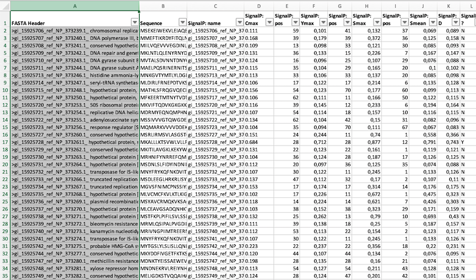

# Export to simple text file

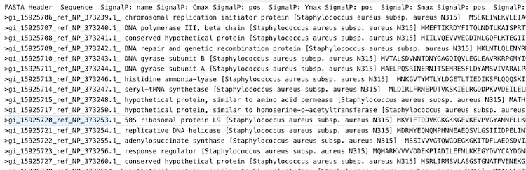

# Loading into R using read.table()

Here is how you load data files in R  
No mouse clicks!

```r
protein_data <- read.table(file = "data/protein_processing_pred.csv",
                        header = TRUE,
                        sep = ";",
                        dec = ",",
                        as.is = c(1, 2, 3, 21))
```

Don’t worry - you do not need to be able to do this for the test. The next slide explains what happens.

```r
protein_data <- read.table(file = "data/protein_processing_pred.csv",
                        header = TRUE,
                        sep = ";",
                        dec = ",",
                        as.is = c(1, 2, 3, 21))
```

- `read.table` is the function you use to load data from a file. It accepts many optional arguments and only one mandatory - the file name.
- the *key = value pairs* between the parentheses such as `sep = ";"` and `header=TRUE` are the function arguments that specify where the file is and how it should be loaded.
- the data are assigned to a variable called `protein_data`.
- type `?read.table` if you are interested in the details.

# Inspect the data: column names

```r
names(protein_data)
```

```
 [1] "FASTA_Header"          "Sequence"              "SignalP_name"          "SignalP_Cmax"
 [5] "SignalP_Cmax_pos"      "SignalP_Ymax"          "SignalP_Ymax_pos"      "SignalP_Smax"
 [9] "SignalP_Smax_pos"      "SignalP_Smean"         "SignalP_D"             "SignalP_YesNo"
[13] "SignalP_Dmaxcut"       "SignalP_Networks_used" "LipoP_Localisation"    "LipoP_Score"
[17] "TMHMM_Length"          "TMHMM_ExpAA"           "TMHMM_First60"         "TMHMM_PredHel"
[21] "TMHMM_Topology"
```

# Inspect the data: the first few entries

```r
head(protein_data)
```

```
                                                                                                          FASTA_Header
1    gi_15925706_ref_NP_373239.1_ chromosomal replication initiator protein [Staphylococcus aureus subsp. aureus N315]
2               gi_15925707_ref_NP_373240.1_ DNA polymerase III, beta chain [Staphylococcus aureus subsp. aureus N315]
3               gi_15925708_ref_NP_373241.1_ conserved hypothetical protein [Staphylococcus aureus subsp. aureus N315]
4 gi_15925709_ref_NP_373242.1_ DNA repair and genetic recombination protein [Staphylococcus aureus subsp. aureus N315]
5                         gi_15925710_ref_NP_373243.1_ DNA gyrase subunit B [Staphylococcus aureus subsp. aureus N315]
6                         gi_15925711_ref_NP_373244.1_ DNA gyrase subunit A [Staphylococcus aureus subsp. aureus N315]
                                                                                                                                                                                                                                                                                                            …
1                                                                                                                                                                                                                                                                                                           …
2                                                                                                                                                                                                                                                                                                           …
3                                                                                                                                                                                                                                                                                                           …
4                                                                                                                                                                                                                                                                                                           …
5                                                                                                                                                                                                                                                      MVTALSDVNNTDNYGAGQIQVLEGLEAVRKRPGMYIGSTSERGLHHLVWEIVD…
6 MAELPQSRINERNITSEMRESFLDYAMSVIVARALPDVRDGLKPVHRRILYGLNEQGMTP…
                  SignalP_name SignalP_Cmax SignalP_Cmax_pos SignalP_Ymax SignalP_Ymax_pos
```

[output cut: 27 more lines]

# Inspect the data: View like Excel

If you want to have a look at the data “spreadsheet-style”, you can type `View(prot_data)` in the Console. The Viewer will show the data associated with the variable in the editor panel.

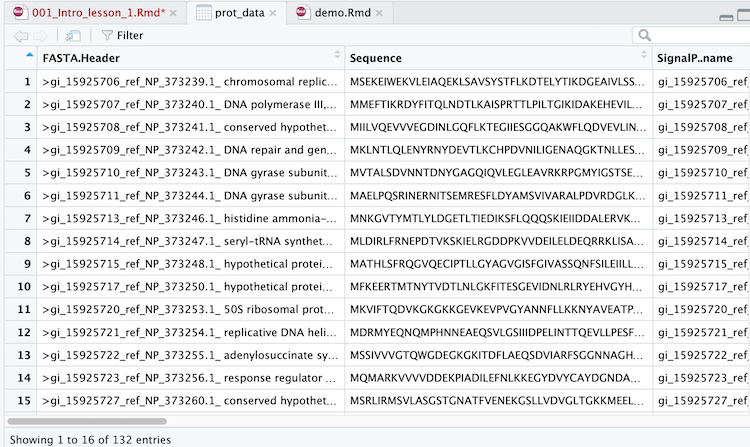

# DATAFRAMES

# What is a dataframe

- The dataset `protein_data` is what is called a **dataframe** in R.
- In a dataframe, data is organized in rows and columns.
- Columns contain *measurements* of a single variable; they are formed by vectors.
- Rows contain *observations* (here: different measurements on a protein).
- A dataframe is an ordered list of vectors of the same length.

# Accessing a column of a dataframe

- Use the dollar sign `$` to get hold of a single columnm

```r
protein_data$SignalP_YesNo
```

```
  [1] N N N N N N N N N N N N N N N Y N N N N N N N N N N N N N N N N N N N N N N N N N N N N N N N
 [48] N N N N N N N N N N N N N N N N N N N N N N N N N Y N N N Y Y N N N N N N Y N N Y N N N N N N
 [95] N N N N N N N N N N N N N N N Y Y N N N N N N Y Y N Y Y N Y N N Y N Y Y Y N Y N N Y N Y Y N N
[142] Y Y Y Y Y Y Y Y Y Y Y Y N Y Y N Y Y Y Y N Y N N N N N N N Y N Y N N Y N N N Y N N Y N N N Y N
[189] Y N N N N Y Y N Y Y Y Y Y Y N N N N Y N N N Y N N Y N N Y Y Y Y Y N N Y N Y N N N Y Y Y Y Y Y
[236] Y N Y Y Y N N N N N N N N N Y N N N Y Y Y N N Y N N N N N N N N N N N N N N Y Y Y Y N Y Y Y Y
[283] Y N Y Y N N Y N N N N N Y Y N N N Y Y Y Y Y N N N Y Y Y Y Y N N N N N N N N Y N N N N Y Y N N
[330] N Y N Y Y Y N N N N N Y N N Y Y N Y N Y Y Y Y N N N N N N Y N Y Y N N Y N N N N Y N N N Y Y Y
[377] Y Y Y Y N Y Y Y N N N
Levels: N Y
```

- Here is a table summary of column “SignalP_YesNo”, showing that 134 out of 387 proteins have a putative signal sequence:

```r
table(protein_data$SignalP_YesNo)
```

```
  N   Y
253 134
```

Since it is a vector, you can use indexing on a column:

```r
protein_data$SignalP_YesNo[330:345]
```

```
 [1] N Y N Y Y Y N N N N N Y N N Y Y
Levels: N Y
```

# The number of rows and columns

Get the dimensions of the dataset:

```r
dim(protein_data)
```

```
[1] 387  21
```

This is a vector of two integers. Which one is the number of rows?

# Indexing on dataframes

- Indexing on whole dataframes is like using a coordinate system:  
  `dataframe[rows, columns]`
- Leave empty if you want all values of the row or column
- The next few slides use this example dataframe called `students`

```r
students <- data.frame(sid=paste0("S0", 1:5),
                       name=c("Mark", "Lynn", "Lianne", "Peter", "Rose"),
                       sex=factor(c("m", "f", "f", "m", "f"),
                                  labels = c("female", "male")),
                       biology=c(5.6, 6.2, 7.9, 4.4, 9.1),
                       statistics=c(6.1, 5.1, 8.0, 4.7, 7.3),
                       informatics=c(6.3, 6.1, 7.7, 5.4, 9.5),
                       stringsAsFactors = F)
students
```

```
  sid   name    sex biology statistics informatics
1 S01   Mark   male     5.6        6.1         6.3
2 S02   Lynn female     6.2        5.1         6.1
3 S03 Lianne female     7.9        8.0         7.7
4 S04  Peter   male     4.4        4.7         5.4
5 S05   Rose female     9.1        7.3         9.5
```

```
  sid   name    sex biology statistics informatics
1 S01   Mark   male     5.6        6.1         6.3
2 S02   Lynn female     6.2        5.1         6.1
3 S03 Lianne female     7.9        8.0         7.7
4 S04  Peter   male     4.4        4.7         5.4
5 S05   Rose female     9.1        7.3         9.5
```

```r
students[1, 2] # row 1, second value
```

```
[1] "Mark"
```

```r
students[2, 4:6] # all grades of Lynn
```

```
  biology statistics informatics
2     6.2        5.1         6.1
```

```
  sid   name    sex biology statistics informatics
1 S01   Mark   male     5.6        6.1         6.3
2 S02   Lynn female     6.2        5.1         6.1
3 S03 Lianne female     7.9        8.0         7.7
4 S04  Peter   male     4.4        4.7         5.4
5 S05   Rose female     9.1        7.3         9.5
```

```r
students[, 2] # all student names - same as students$name
```

```
[1] "Mark"   "Lynn"   "Lianne" "Peter"  "Rose"
```

```r
students[2, ] # row 2
```

```
  sid name    sex biology statistics informatics
2 S02 Lynn female     6.2        5.1         6.1
```

# Using logical selections

```
  sid   name    sex biology statistics informatics
1 S01   Mark   male     5.6        6.1         6.3
2 S02   Lynn female     6.2        5.1         6.1
3 S03 Lianne female     7.9        8.0         7.7
4 S04  Peter   male     4.4        4.7         5.4
5 S05   Rose female     9.1        7.3         9.5
```

All grades for Lynn:

```r
students[students$name == "Lynn", 4:6]
```

```
  biology statistics informatics
2     6.2        5.1         6.1
```

```
  sid   name    sex biology statistics informatics
1 S01   Mark   male     5.6        6.1         6.3
2 S02   Lynn female     6.2        5.1         6.1
3 S03 Lianne female     7.9        8.0         7.7
4 S04  Peter   male     4.4        4.7         5.4
5 S05   Rose female     9.1        7.3         9.5
```

All grades for girls:

```r
students[students$sex == "female", ]
```

```
  sid   name    sex biology statistics informatics
2 S02   Lynn female     6.2        5.1         6.1
3 S03 Lianne female     7.9        8.0         7.7
5 S05   Rose female     9.1        7.3         9.5
```

# –Practice 6–

To get the student data into your session, type `source("https://git.io/fjfMW")` in the console. It is this file: https://raw.githubusercontent.com/MichielNoback/intro_R_lessons/gh-pages/data/intro_lesson_data.R

Type `students` or `View(students)` in the console to verify you have it

# –Practice 6 Solutions–

1: select all `informatics` grades: two alternatives

```r
students$informatics
```

```
[1] 6.3 6.1 7.7 5.4 9.5
```

```r
students[, 6]
```

```
[1] 6.3 6.1 7.7 5.4 9.5
```

```r
students[2:3, ]
```

```
  sid   name    sex biology statistics informatics
2 S02   Lynn female     6.2        5.1         6.1
3 S03 Lianne female     7.9        8.0         7.7
```

```r
students[c(2, 3), ]
```

```
  sid   name    sex biology statistics informatics
2 S02   Lynn female     6.2        5.1         6.1
3 S03 Lianne female     7.9        8.0         7.7
```

3: select the `statistics` grade for Peter: three alternatives

```r
students[4, 5] # simple but not really the intention
```

```
[1] 4.7
```

```r
students$statistics[4] # idem
```

```
[1] 4.7
```

```r
students[students$name == "Peter", 5] # better
```

```
[1] 4.7
```

4: select the biology and statistics grades for the female students

```r
students[students$sex == "female", c(4, 5)]
```

```
  biology statistics
2     6.2        5.1
3     7.9        8.0
5     9.1        7.3
```

5: select the student names where the biology grade is below 6

```r
students[students$biology < 6, 2]
```

```
[1] "Mark"  "Peter"
```

# CREATING FIGURES

# Load the data yourself.

If you want to tag along, download and load the file as follows:

```r
protein_data <- read.table(file = "https://git.io/fjfum",
                        header = TRUE,
                        sep = ";",
                        dec = ",",
                        as.is = c(1, 2, 3, 21))
```

(if the short URL does not work, use  
“https://raw.githubusercontent.com/MichielNoback/intro_R_lessons/gh-pages/data/protein_processing_pred.csv”)

# A scatterplot

Let’s investigate the relation Cmax vs Ymax of the SignalP analysis:

```r
head(protein_data$SignalP_Cmax)
```

```
[1] 0.111 0.168 0.109 0.131 0.124 0.115
```

```r
head(protein_data$SignalP_Ymax)
```

```
[1] 0.101 0.179 0.098 0.133 0.096 0.104
```

See http://www.cbs.dtu.dk/services/SignalP-4.1/output.php for a description of these analysis results.

Create variables for convenience, and plot:

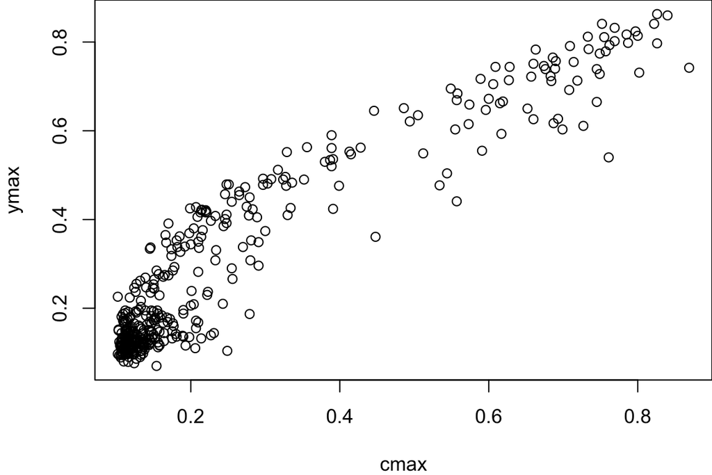

```r
cmax <- protein_data$SignalP_Cmax
ymax <- protein_data$SignalP_Ymax
plot(x = cmax, y = ymax)
```

# Tweak a little

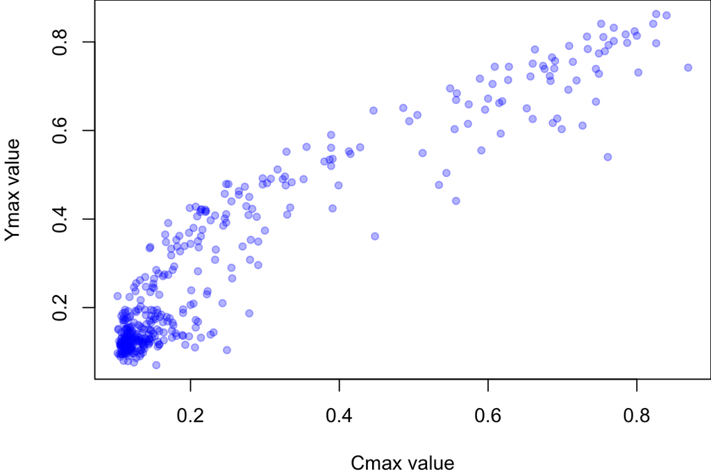

```r
plot(x = cmax, y = ymax,
     xlab = "Cmax value", ylab="Ymax value",
     pch=19, cex = 0.8, col=rgb(0, 0, 1, 0.3))
```

Or, even better, with a log transform:

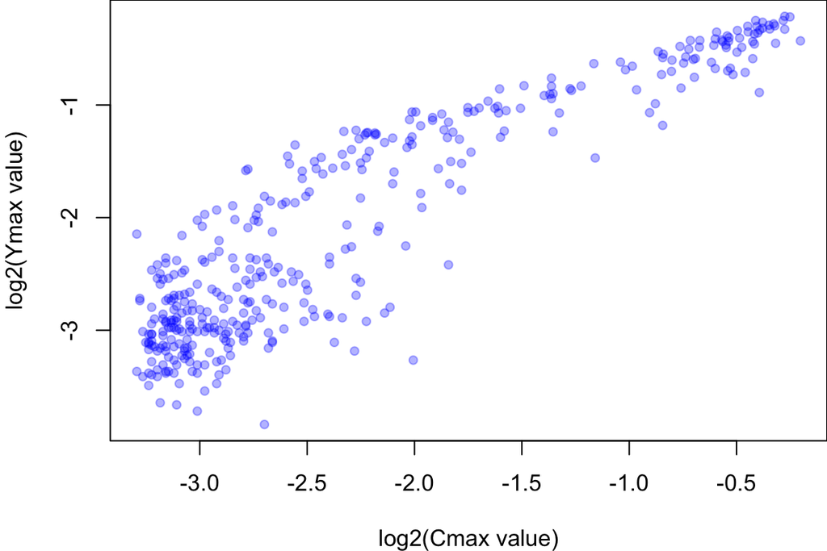

```r
plot(x = log2(cmax), y = log2(ymax),
     xlab = "log2(Cmax value)", ylab="log2(Ymax value)",
     pch=19, cex = 0.8, col=rgb(0, 0, 1, 0.3))
```

# Add a regression line

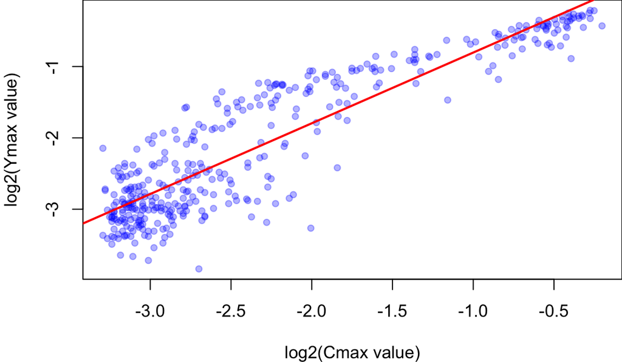

```r
plot(x = log2(cmax), y = log2(ymax),
     xlab = "log2(Cmax value)", ylab="log2(Ymax value)",
     pch=19, cex = 0.8, col=rgb(0, 0, 1, 0.3))
model <- lm(log2(ymax)  ~  log2(cmax))
abline(model, col = "red", lwd=2)
```

# Summary

- You have seen R at work over a variety of activities, including basic plotting.
- Creating a thorough analysis is quite some work - as with any analysis platform, but repeating the analysis with new data is as simple as a mouse click.
- Advise: use RMarkdown whenever you are going to do a data analysis project.

# On the test

What is expected of you at the test of this course:

You should be be able to

- perform basic mathematic operations
- apply selections on vectors and dataframes
- read documentation for a function
- use existing functions correctly

You will be allowed to use all R documentation as well as this presentation.

# FINAL ASSIGNMENT

# Final assignment

Download the assignment RMarkdown document from this location:

https://git.io/JeOIh

Long URL:  
https://michielnoback.github.io/intro_R_lessons/final_assignment_R_BMR.Rmd  
Web-page view:  
https://michielnoback.github.io/intro_R_lessons/final_assignment_R_BMR.html

Save the file on your computer, open it in RStudio and then deal with the assignments. Put your solutions where it says  
`## YOUR CODE HERE`.

You can process the document into Word form by klicking “Knit” Submit this Word document.